# Stroop Color-Word Test Scoring Report

#### Color-Word

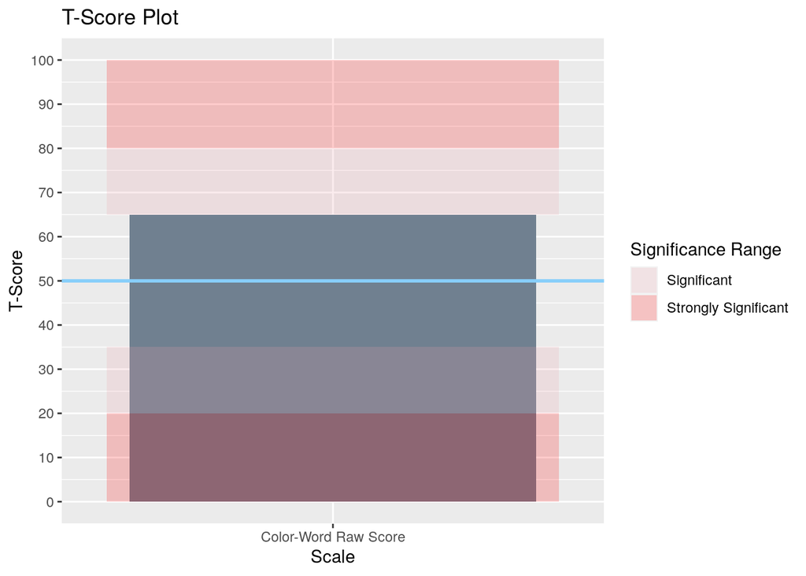

#### Color

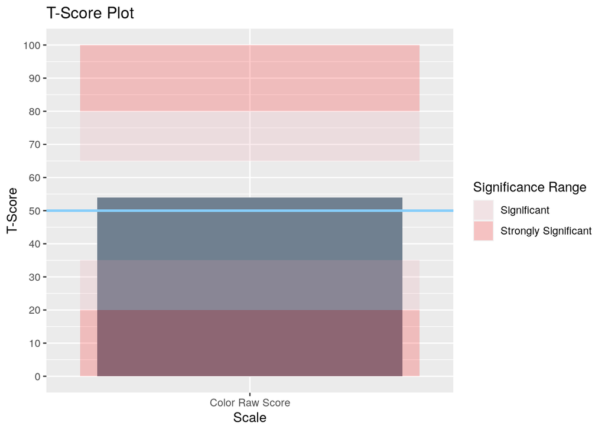

Stewart scored 54 on Color. This score is within +/- 1 SD from the mean, average compared to peers. This scale is an assessment of ability to discern and identify colors. Color vision impairment would influence performance in this domain and must be considered. Performance on this domain should be evaluated with others to identify global abilities or as a reflection of effort.

#### Word

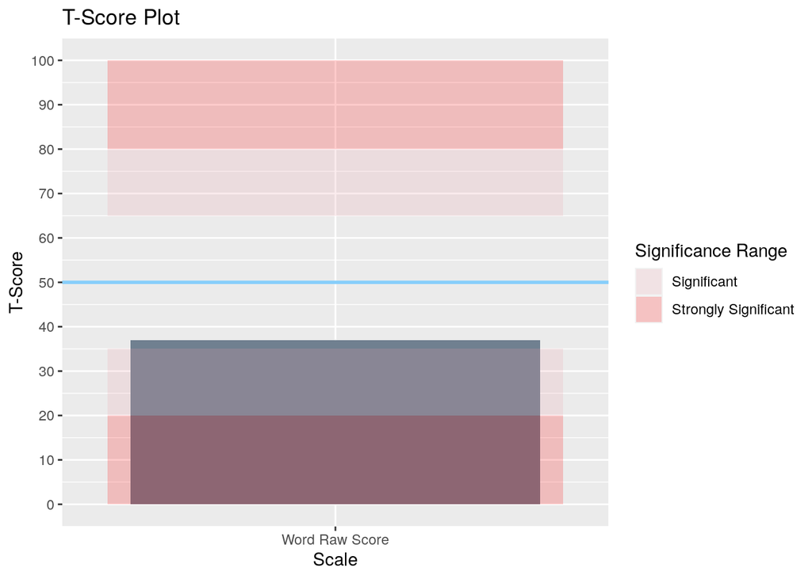

[figure not shown]

Copyright 2021:[Stoelting](https://www.stoeltingco.com)

*Email Stoelting for support*